# OMRRAY001 JULIA ASSIGNMENT 2

I know that plagiarism is wrong. Plagiarism is to use another’s work and pretend that it is one’s own.

I have used no convention for citation and referencing. Each contribution to, and quotation in, this report from the work(s) of other people has been attributed, and has been referenced.

This report is my own work.

I have not allowed, and will not allow, anyone to copy my work with the intention of passing it off as his or her own work.

## Question 6.1a

### (i)

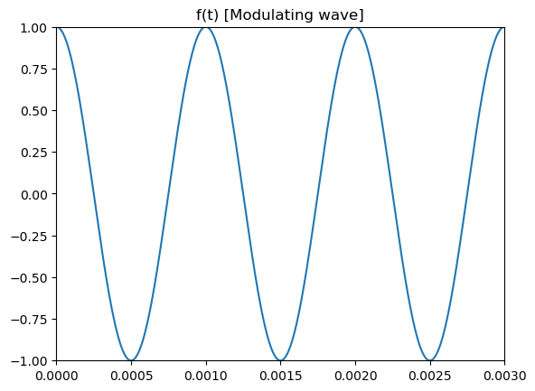

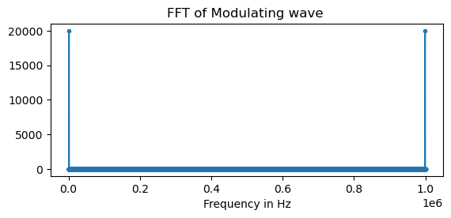

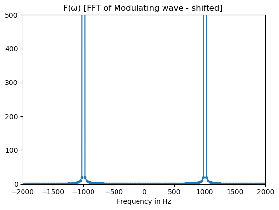

```julia
# Importing useful libraries
using PyPlot
using FFTW

# Create array for t + related variables
Δt=0.000001;
t=0:Δt:0.04;
N = length(t)
Δf = 1/(N*Δt)  # spacing in frequency domain


# Create waves/signals  + related variables
fc=20000;
fm=1000;
f=cos.(2π*fm.*t)
c=cos.(2π*fc.*t)
ϕ=f.*c


# Fourier Transforms of each wave
F = fft(f);
C=fft(c);
Φ=fft(ϕ);

#create array of freq values stored in f_axis. First element maps to 0Hz (for fft)
f_axis = (0:N-1)*Δf;
#Label the frequency axis in Hz
N = length(t);
Δf = 1/(N*Δt)  # spacing in frequency domain

#create array of freq values stored in f_axis. (for fftshift)
if mod(N,2)==0    # case N even
    f_axisSh = (-N/2:N/2-1)*Δf;
else   # case N odd
    f_axisSh = (-(N-1)/2 : (N-1)/2)*Δf;
end


# Plotting of modulating wave
figure(); plot(t,f);
PyPlot.title("f(t) [Modulating wave]");
plt.axis([0, 0.003, -1, 1]);

# Plotting of modulating wave's fft
figure(figsize=(6.4,2.5)); plot(f_axis, abs.(F),".-");
xlabel("Frequency in Hz");
PyPlot.title("FFT of Modulating wave ");

# Plotting of modulating wave's fft after fftshift
figure(figsize=(6.4,4.5));
PyPlot.margins(x=-0.4,y=0.1);
plot(f_axisSh, fftshift(abs.(F)),".-");
xlabel("Frequency in Hz");
plt.axis([-2000, 2000, 0, 500]);
PyPlot.title("F(ω) [FFT of Modulating wave - shifted] ");
```

### 6.1a (ii)

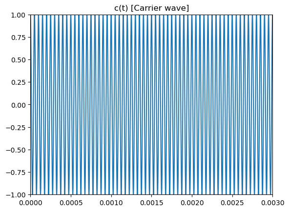

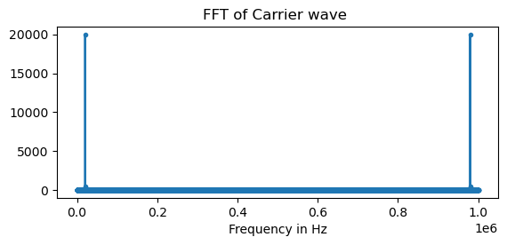

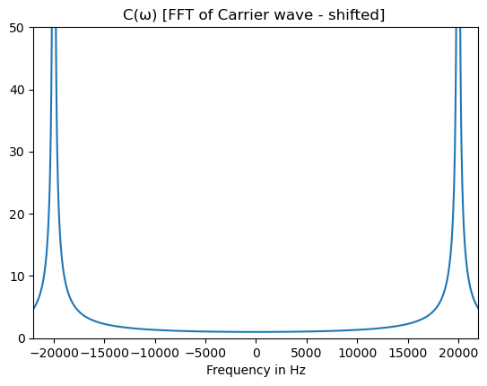

```julia
# Plotting of carrier wave
figure();plot(t,c);PyPlot.title("c(t) [Carrier wave]");plt.axis([0, 0.003, -1, 1]);

# Plotting of carrrier wave's fft
figure(figsize=(6.4,2.5)); plot(f_axis, abs.(C),".-");xlabel("Frequency in Hz");PyPlot.title("FFT of Carrier wave ");

# Plotting of carrier wave's fft after fftshift
figure(figsize=(6.4,4.5)); PyPlot.margins(x=-0.4,y=0.1); plot(f_axisSh, fftshift(abs.(C)),"-"); xlabel("Frequency in Hz");
plt.axis([-22000, 22000, 0, 50]);PyPlot.title("C(ω) [FFT of Carrier wave - shifted] ");
```

### 6.1a (iii)

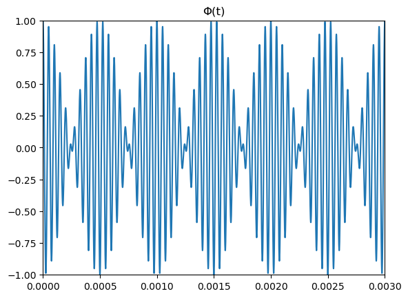

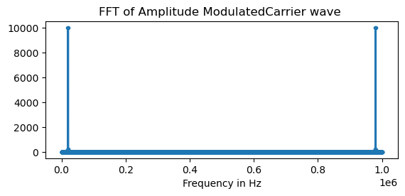

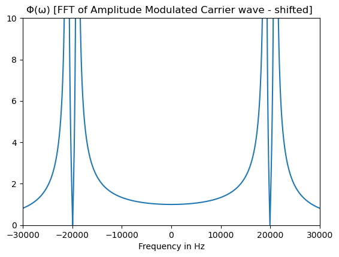

```julia
# Plotting of amplitude modulated carrrier wave
figure();plot(t,ϕ);PyPlot.title("Φ(t)");plt.axis([0, 0.003, -1, 1]);


# Plotting of amplitude modulated carrrier wave's fft
figure(figsize=(6.4,2.5)); plot(f_axis, abs.(Φ),".-");xlabel("Frequency in Hz");
PyPlot.title("FFT of Amplitude ModulatedCarrier wave ");


# Plotting of amplitude modulated carrier wave's fft after fftshift
figure(figsize=(6.4,4.5)); PyPlot.margins(x=-0.4,y=0.1); plot(f_axisSh, fftshift(abs.(Φ)),"-"); xlabel("Frequency in Hz");
plt.axis([-30000, 30000, 0, 10]);PyPlot.title("Φ(ω) [FFT of Amplitude Modulated Carrier wave - shifted] ");
```

It can be a bit difficult to tell but the sidebands are 1000 Hz away from the carrier frequency. The reason it is hard to tell is because the FFT is imperfect and so is the scaling of this plot. The plot has been scaled this way to show a clear distinction between the sidebands and the carrier frequency.

#### Answers to questions

- If the frequency of the modulating frequency is doubled, then the sidebands move away from the carrier frequency (from 1000 Hz away to 2000 Hz away)
- If the ampltitude of the modulating frequency is doubled, then the magnitude of the sidebands is also doubled

### 6.1a (iv)

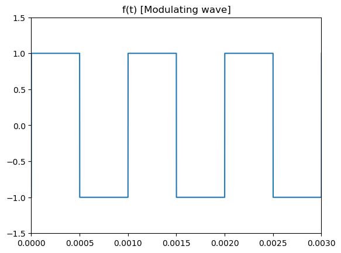

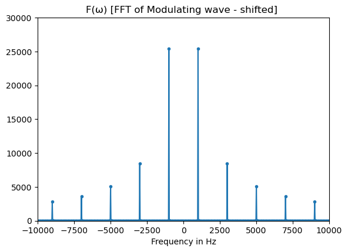

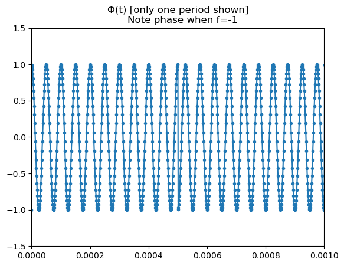

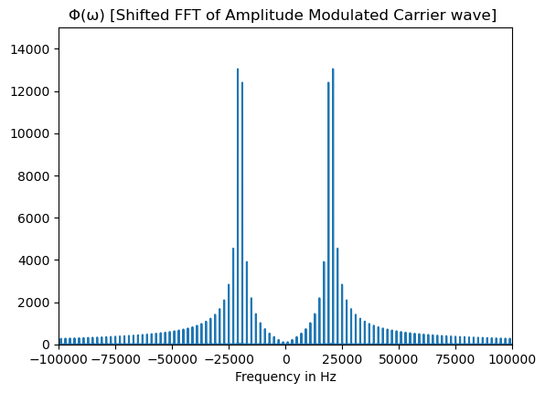

```julia
# Importing useful libraries
using PyPlot
using FFTW

# Create array for t + related variables
Δt=0.000001;
t=0:Δt:0.04;
N = length(t)


# Create waves/signals  + related variables
fc=20000;
fm=1000;
square_wave(t) = ( (sin.(2*pi*fm*t) .> 0) .- 0.5 )*2 # square wave -1,+1
f=square_wave(t);
c=cos.(2π*fc.*t)
ϕ=f.*c
ϕ=f.*c


# Fourier Transforms of each wave
F = fft(f);
C=fft(c);
Φ=fft(ϕ);

#create array of freq values stored in f_axis. First element maps to 0Hz (for fft)
f_axis = (0:N-1)*Δf;
#Label the frequency axis in Hz
N = length(t);
Δf = 1/(N*Δt)  # spacing in frequency domain

#create array of freq values stored in f_axis. (for fftshift)
if mod(N,2)==0    # case N even
    f_axisSh = (-N/2:N/2-1)*Δf;
else   # case N odd
    f_axisSh = (-(N-1)/2 : (N-1)/2)*Δf;
end

# Plotting of modulating wave
figure(); plot(t,f);
PyPlot.title("f(t) [Modulating wave]");
plt.axis([0, 0.003, -1.5, 1.5]);


# Plotting of modulating wave's fft after fftshift
figure(figsize=(6.4,4.5));
PyPlot.margins(x=-0.4,y=0.1);
plot(f_axisSh, fftshift(abs.(F)),".-");
xlabel("Frequency in Hz");
plt.axis([-10000, 10000, 0, 30000]);
PyPlot.title("F(ω) [FFT of Modulating wave - shifted] ");

# Plotting of amplitude modulated carrrier wave
figure();plot(t,ϕ,".-");PyPlot.title("Φ(t) [only one period shown]
    Note phase when f=-1 ");plt.axis([0, 0.001, -1.5, 1.5]);


# Plotting of amplitude modulated carrier wave's fft after fftshift
figure(figsize=(6.4,4.5)); PyPlot.margins(x=-0.4,y=0.1); plot(f_axisSh, fftshift(abs.(Φ)),"-"); xlabel("Frequency in Hz");
plt.axis([-100000, 100000, 0, 15000]);PyPlot.title("Φ(ω) [Shifted FFT of Amplitude Modulated Carrier wave] ");
```

#### Answers:

Quite a few frequencies are present in the spectrum of ϕ(t). All are odd harmonics centered at +/- 20 kHz with those closer to the center being higher in magnitude

## Question 6.1b

### (i)

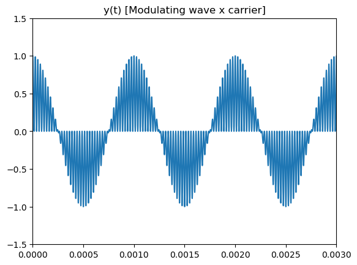

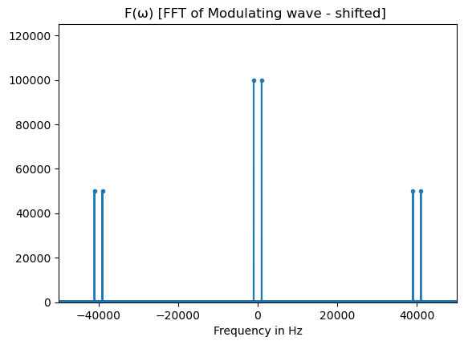

```julia
# Importing useful libraries
using PyPlot
using FFTW

# Create array for t + related variables
Δt=0.0000001;
t=0:Δt:0.04;
N = length(t)


# Create waves/signals  + related variables
fc=20000;
fm=1000;
f=cos.(2π*fm.*t)
c=cos.(2π*fc.*t)
ϕ=f.*c


# Fourier Transforms of each wave
F = fft(f);
C=fft(c);
Φ=fft(ϕ);

#create array of freq values stored in f_axis. First element maps to 0Hz (for fft)
f_axis = (0:N-1)*Δf;
#Label the frequency axis in Hz
N = length(t);
Δf = 1/(N*Δt)  # spacing in frequency domain

#create array of freq values stored in f_axis. (for fftshift)
if mod(N,2)==0    # case N even
    f_axisSh = (-N/2:N/2-1)*Δf;
else   # case N odd
    f_axisSh = (-(N-1)/2 : (N-1)/2)*Δf;
end



#Demodulation step 1: multipliying ϕ with carrier
ϕc=ϕ.*c
ΦC=fft(ϕc);

# Plotting of modulating wave x carrier
figure(); plot(t,ϕc);
PyPlot.title("y(t) [Modulating wave x carrier]");
plt.axis([0, 0.003, -1.5, 1.5]);


# Plotting of modulating wave x carrier fft after fftshift
figure(figsize=(6.4,4.5));
PyPlot.margins(x=-0.4,y=0.1);
plot(f_axisSh, fftshift(abs.(ΦC)),".-");
xlabel("Frequency in Hz");
plt.axis([-50000, 50000, 0, 125000]);
PyPlot.title("F(ω) [FFT of Modulating wave - shifted] ");
```

### 6.1b (ii)

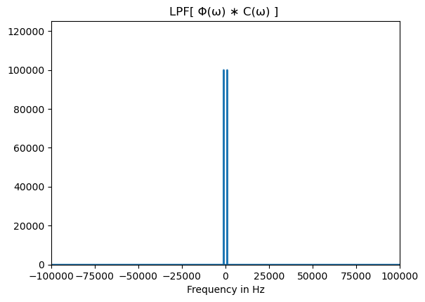

```julia
#LPF prep
Cutoff=5000; #cutoff frequency
ΔN= floor(Int,(Cutoff/(8*pi*N))*N) #find cuttoff indexes for array with N values

#Demodulation step 2: applying LPF to Φ(ω) ∗ C(ω)
lpfΦC=ΦC
lpfΦC[ΔN:N-ΔN].=0;

# Plotting LPF[ Φ(ω) ∗ C(ω) ]
figure(figsize=(6.4,4.5)); PyPlot.margins(x=-0.4,y=0.1); plot(f_axisSh, fftshift(abs.(lpfΦC)),"-"); xlabel("Frequency in Hz");
plt.axis([-100000, 100000, 0, 125000]);PyPlot.title("LPF[ Φ(ω) ∗ C(ω) ] ");
```

High frequency components have been seemingly removed

### 6.1b (iii)

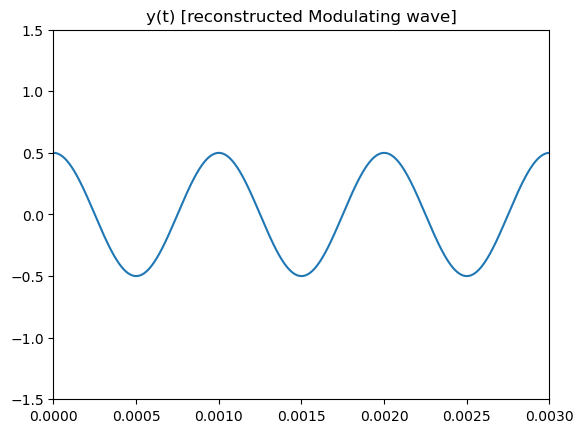

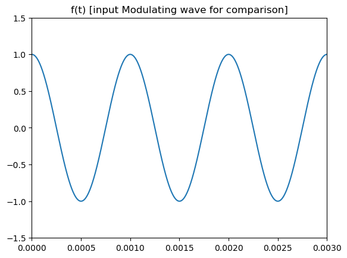

```julia
#Demodulation step 3: apply inverse fft to LPF[ Φ(ω) ∗ C(ω) ] to get 0.5f(t) signal
fd = real(ifft(lpfΦC))

# Plotting of reconstructed modulating wave
figure(); plot(t,real(fd));
PyPlot.title("y(t) [reconstructed Modulating wave]");
plt.axis([0, 0.003, -1.5, 1.5]);

# Plotting of orignial modulating wave
figure(); plot(t,f);
PyPlot.title("f(t) [input Modulating wave for comparison]");
plt.axis([0, 0.003, -1.5, 1.5]);
```

#### Answers

- the final output does seem to agree with the theory (that it has half the amplitude of the modulating wave)

## Question 6.1c

### (i)

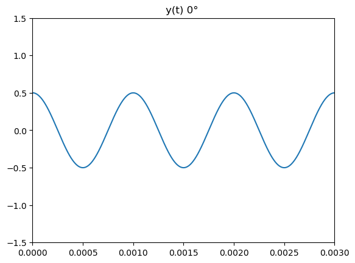

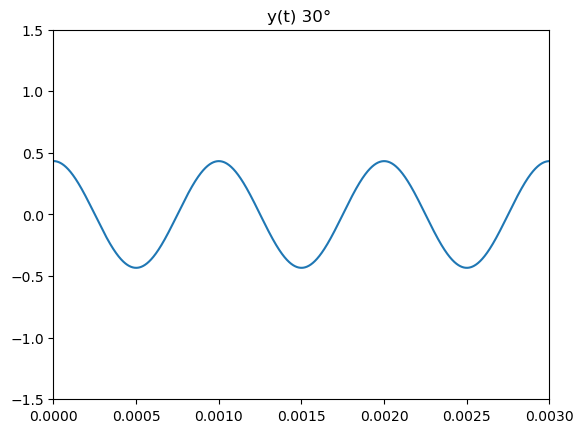

```julia
# Importing useful libraries
using PyPlot
using FFTW

# Create array for t + related variables
Δt=0.0000001;
t=0:Δt:0.04;
N = length(t)


# Create waves/signals  + related variables
fc=20000;
fm=1000;
f=cos.(2π*fm.*t)
c=cos.(2π*fc.*t)
ϕ=f.*c


# Fourier Transforms of each wave
F = fft(f);
C=fft(c);
Φ=fft(ϕ);

#create array of freq values stored in f_axis. First element maps to 0Hz (for fft)
f_axis = (0:N-1)*Δf;
#Label the frequency axis in Hz
N = length(t);
Δf = 1/(N*Δt)  # spacing in frequency domain

#create array of freq values stored in f_axis. (for fftshift)
if mod(N,2)==0    # case N even
    f_axisSh = (-N/2:N/2-1)*Δf;
else   # case N odd
    f_axisSh = (-(N-1)/2 : (N-1)/2)*Δf;
end


#phase shifted carrier waves
c30=cos.(2π*fc.*t .+ π/6);
c60=cos.(2π*fc.*t .+ π/3);
c85=cos.(2π*fc.*t .+ (85π/180));
c90=cos.(2π*fc.*t .+ π/2);



#Demodulation step 1: multipliying ϕ with carrier

ϕc=ϕ.*c;
ΦC=fft(ϕc);

#Demodulation step 2: applying LPF to Φ(ω) ∗ C(ω)
lpfΦC=ΦC
lpfΦC[ΔN:N-ΔN].=0;

#Demodulation step 3: apply inverse fft to LPF[ Φ(ω) ∗ C(ω) ] to get 0.5f(t) signal
fd = real(ifft(lpfΦC))

# Plotting of reconstructed modulating wave
figure(); plot(t,real(fd));
PyPlot.title("y(t) 0° ");
plt.axis([0, 0.003, -1.5, 1.5]);




#Demodulation step 1: multipliying ϕ with carrier (but with 30° phase shift)

ϕc=ϕ.*c30;
ΦC=fft(ϕc);

#Demodulation step 2: applying LPF to Φ(ω) ∗ C(ω)
lpfΦC=ΦC
lpfΦC[ΔN:N-ΔN].=0;

#Demodulation step 3: apply inverse fft to LPF[ Φ(ω) ∗ C(ω) ] to get 0.5f(t) signal
fd = real(ifft(lpfΦC))

# Plotting of reconstructed modulating wave
figure(); plot(t,real(fd));
PyPlot.title("y(t) 30° ");
plt.axis([0, 0.003, -1.5, 1.5]);
```

### 6.1c (ii)

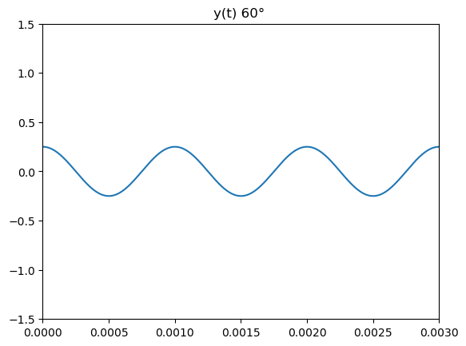

```julia
#Demodulation step 1: multipliying ϕ with carrier (but with 60° phase shift)

ϕc=ϕ.*c60;
ΦC=fft(ϕc);

#Demodulation step 2: applying LPF to Φ(ω) ∗ C(ω)
lpfΦC=ΦC
lpfΦC[ΔN:N-ΔN].=0;

#Demodulation step 3: apply inverse fft to LPF[ Φ(ω) ∗ C(ω) ] to get 0.5f(t) signal
fd = real(ifft(lpfΦC))

# Plotting of reconstructed modulating wave
figure(); plot(t,real(fd));
PyPlot.title("y(t) 60° ");
plt.axis([0, 0.003, -1.5, 1.5]);
```

### 6.1c (iii)

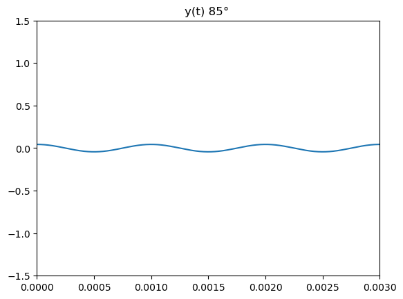

```julia
#Demodulation step 1: multipliying ϕ with carrier (but with 85° phase shift)

ϕc=ϕ.*c85;
ΦC=fft(ϕc);

#Demodulation step 2: applying LPF to Φ(ω) ∗ C(ω)
lpfΦC=ΦC
lpfΦC[ΔN:N-ΔN].=0;

#Demodulation step 3: apply inverse fft to LPF[ Φ(ω) ∗ C(ω) ] to get 0.5f(t) signal
fd = real(ifft(lpfΦC))

# Plotting of reconstructed modulating wave
figure(); plot(t,real(fd));
PyPlot.title("y(t) 85° ");
plt.axis([0, 0.003, -1.5, 1.5]);
```

### 6.1c (iv)

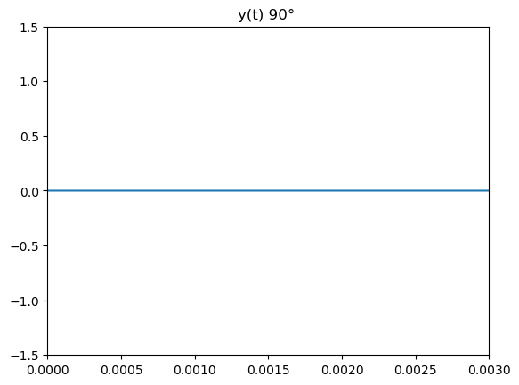

```julia
#Demodulation step 1: multipliying ϕ with carrier (but with 90° phase shift)

ϕc=ϕ.*c90;
ΦC=fft(ϕc);

#Demodulation step 2: applying LPF to Φ(ω) ∗ C(ω)
lpfΦC=ΦC
lpfΦC[ΔN:N-ΔN].=0;

#Demodulation step 3: apply inverse fft to LPF[ Φ(ω) ∗ C(ω) ] to get 0.5f(t) signal
fd = real(ifft(lpfΦC))

# Plotting of reconstructed modulating wave
figure(); plot(t,real(fd));
PyPlot.title("y(t) 90° ");
plt.axis([0, 0.003, -1.5, 1.5]);
```

## Exercise 6.1d

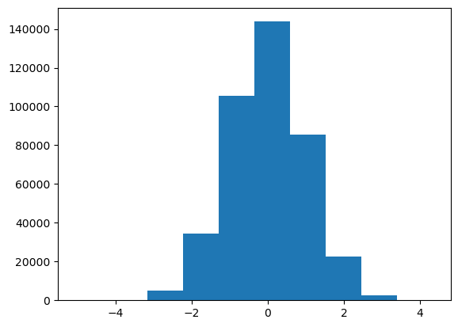

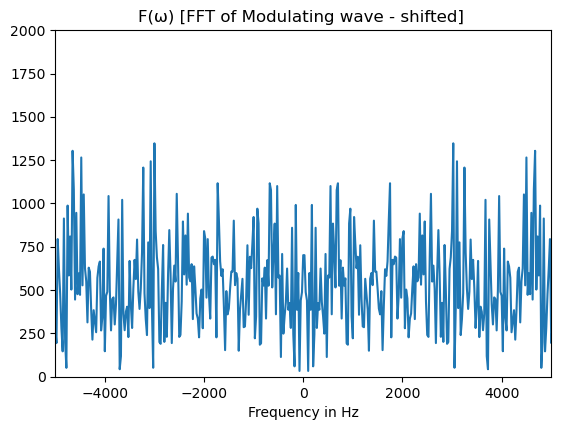

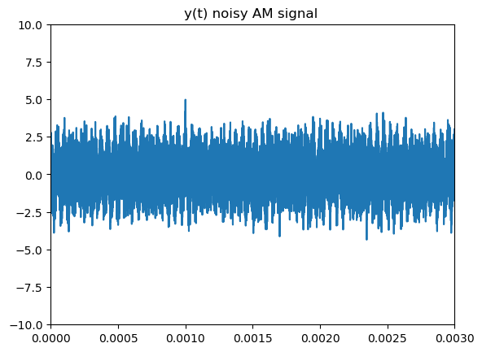

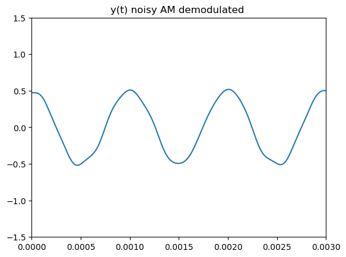

```julia
σ=1;
noise = σ*randn(N);

figure(); hist(noise);

NOISE=fft(noise);

# Plotting of Noise fft after fftshift
figure(figsize=(6.4,4.5));
PyPlot.margins(x=-0.4,y=0.1);
plot(f_axisSh, fftshift(abs.(NOISE),"-"));
xlabel("Frequency in Hz");
plt.axis([-5000, 5000, 0, 2000]);
PyPlot.title("F(ω) [FFT of Modulating wave - shifted] ");



#Demodulation step 1: multipliying ϕ with carrier
ϕn=ϕ+noise
ϕnc=ϕn.*c;
ϕnc85=ϕn.*c85;

ΦNC=fft(ϕnc);

#Demodulation step 2: applying LPF to Φ(ω) ∗ C(ω)
lpfΦNC=ΦNC
lpfΦNC[ΔN:N-ΔN].=0;

#Demodulation step 3: apply inverse fft to LPF[ Φ(ω) ∗ C(ω) ] to get 0.5f(t) signal
fd = real(ifft(lpfΦNC))

# Plotting of noisy AM signal modulating wave
figure(); plot(t,real(ϕn));
PyPlot.title("y(t) noisy AM signal ");
plt.axis([0, 0.003, -10,10 ]);

# Plotting of reconstructed modulating wave (from noisy AM) modulating wave
figure(); plot(t,real(fd));
PyPlot.title("y(t) noisy AM demodulated ");
plt.axis([0, 0.003, -1.5, 1.5]);
```

### 6.1d (1)

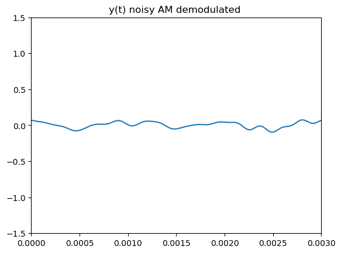

```julia
ΦNC85=fft(ϕnc85);


#Demodulation step 2: applying LPF to Φ(ω) ∗ C(ω)
lpfΦNC85=ΦNC85
lpfΦNC85[ΔN:N-ΔN].=0;

#Demodulation step 3: apply inverse fft to LPF[ Φ(ω) ∗ C(ω) ] to get 0.5f(t) signal
fd = real(ifft(lpfΦNC85))

# Plotting of reconstructed modulating wave (from noisy AM) modulating wave
figure(); plot(t,real(fd));
PyPlot.title("y(t) noisy AM demodulated ");
plt.axis([0, 0.003, -1.5, 1.5]);
```

As the output contains a heavily attenuated version of the modulating signal, the signal to noise ratio would definitely be lower, as can be seen in the figure above

## Exercise 6.2

## 6.2a

### (i)

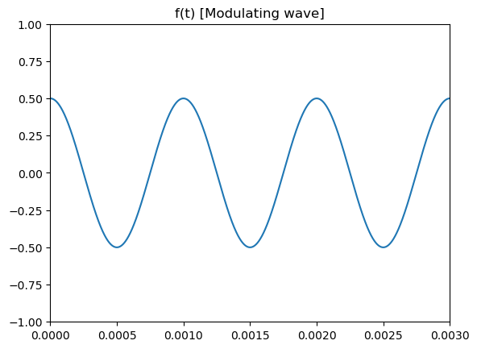

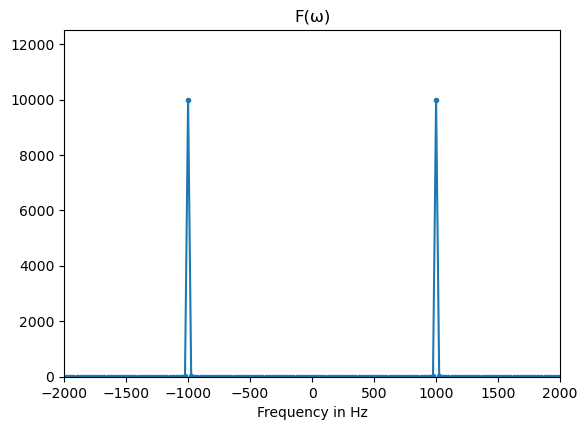

```julia
# Importing useful libraries
using PyPlot
using FFTW

# Create array for t + related variables
Δt=0.000001;
t=0:Δt:0.04;
N = length(t)
Δf = 1/(N*Δt)  # spacing in frequency domain


# Create waves/signals  + related variables
A=1
k=0.5
fc=20000;
fm=1000;
f=k.*cos.(2π*fm.*t)
c=cos.(2π*fc.*t)
ϕ=(f.+A).*c


# Fourier Transforms of each wave
F = fft(f);
C=fft(c);
Φ=fft(ϕ);

#create array of freq values stored in f_axis. First element maps to 0Hz (for fft)
f_axis = (0:N-1)*Δf;
#Label the frequency axis in Hz
N = length(t);
Δf = 1/(N*Δt)  # spacing in frequency domain

#create array of freq values stored in f_axis. (for fftshift)
if mod(N,2)==0    # case N even
    f_axisSh = (-N/2:N/2-1)*Δf;
else   # case N odd
    f_axisSh = (-(N-1)/2 : (N-1)/2)*Δf;
end


# Plotting of modulating wave
figure(); plot(t,f);
PyPlot.title("f(t) [Modulating wave]");
plt.axis([0, 0.003, -1, 1]);


# Plotting of modulating wave's fft after fftshift
figure(figsize=(6.4,4.5));
PyPlot.margins(x=-0.4,y=0.1);
plot(f_axisSh, fftshift(abs.(F)),".-");
xlabel("Frequency in Hz");
plt.axis([-2000, 2000, 0, 12500]);
PyPlot.title("F(ω)");
```